# Resolução da Lista 2 de ADAR

Maicon Fonseca Andrades

18/12/2020

## Critérios de Avaliação

> **Formato padrão de entrega**: só serão avaliadas as listas entregues no [padrão](https://lhmet.github.io/adar-ebook/exerc%C3%ADcios.html) especificado na instrução da referida lista. Entregas fora do padrão implica em nota mínima (zero). O Rmd deve ser baseado no template fornecido.

> **Identificação**: Arquivo .Rmd sem autoria acarreta uma penalização de 5%.

> **Prática de [R Markdown](https://lhmet.github.io/adar-ebook/r-markdown.html)**: A intenção ao solicitar a entrega em R Markdown é de incentivar a prática do R Markdown nas resoluções das questões, incluindo códigos e texto para discutir ou explicar sua solução. A penalização neste critério é até 5% do valor da questão..

> **Boas práticas**: Os códigos são avaliados quanto as boas práticas recomendadas no [livro](https://lhmet.github.io/adar-ebook/boas-pr%C3%A1ticas-para-c%C3%B3digos-de-boa-qualidade.html). Penalização de até 5% do valor questão.

> **Erros de digitação e ortografia**: como há recursos para verificação deste tipo de erro (ver [verificação ortográfica no RStudio](https://lhmet.github.io/adar-ebook/verifica%C3%A7%C3%A3o-ortogr%C3%A1fica.html)) eles são penalizados em até 5% do valor questão.

> **Reprodutibilidade**: o arquivo .Rmd deve rodar sem problemas e gerar o arquivo html com as respostas das questões.

> **Organização**: a resolução das questões devem ser feitas no espaço reservado para ela, ou seja, logo abaixo do enunciado da referida questão no arquivo .Rmd.

> **Adequação**: a lista foi concebida para você aplicar o aprendizado do conteúdo referente ao capítulo da lista. Portanto, a melhor solução é a que aplica as funções pertinentes ao conteúdo daquele capítulo e os pacotes recomendados.

##### 1. Crie um vetor com os valores de $e^{x}cos{x}$ para os valores de $x = (3, 3.1, 3.2, ..., 6$).

```r
x <- seq(from = 3, to = 6, by = 0.1)

#(vetor_result <- exp(x)*cos(x)) # sem addin styler
(vetor_result <- exp(x) * cos(x)) # com addin styler (boas práticas!)
```

```
#>  [1] -19.884531 -22.178753 -24.490697 -26.773182 -28.969238 -31.011186
#>  [7] -32.819775 -34.303360 -35.357194 -35.862834 -35.687732 -34.685042
#> [13] -32.693695 -29.538816 -25.032529 -18.975233 -11.157417  -1.362099
#> [19]  10.632038  25.046705  42.099201  61.996630  84.929067 111.061586
#> [25] 140.525075 173.405776 209.733494 249.468441 292.486707 338.564378
#> [31] 387.360340
```

```
JDT> [1] 0.95
```

##### 2. Crie os seguintes vetores.

- 1. $(0.1^{3}\times0.2^{1}, 0.1^{6}\times0.2^{4}, ..., 0.1^{36}\times0.2^{34})$

```r
aa <- rep(0.1, 12)
bb <- seq(from = 3, to = 36, by = 3)
cc <- rep(0.2, 12)
dd <- seq(from = 1, to = 34, by = 3)

(vetor_solu_a <- aa^bb * cc^dd)
```

```
#>  [1] 2.000000e-04 1.600000e-09 1.280000e-14 1.024000e-19 8.192000e-25
#>  [6] 6.553600e-30 5.242880e-35 4.194304e-40 3.355443e-45 2.684355e-50
#> [11] 2.147484e-55 1.717987e-60
```

- 2. $(2, \frac{2^{2}}{2}, \frac{2^{3}}{3}, ..., \frac{2^{25}}{25})$

```r
j <- seq(from = 1, to = 25, by = 1)

(vetor_solu_b <- (2^j)/j)
```

```
#>  [1] 2.000000e+00 2.000000e+00 2.666667e+00 4.000000e+00 6.400000e+00
#>  [6] 1.066667e+01 1.828571e+01 3.200000e+01 5.688889e+01 1.024000e+02
#> [11] 1.861818e+02 3.413333e+02 6.301538e+02 1.170286e+03 2.184533e+03
#> [16] 4.096000e+03 7.710118e+03 1.456356e+04 2.759411e+04 5.242880e+04
#> [21] 9.986438e+04 1.906502e+05 3.647221e+05 6.990507e+05 1.342177e+06
```

```r
#(vetor_solu_b <- (2^j) / j) # com styler

# código bem mais simples e legível
2^(1:25)/(1:25)
```

```
#>  [1] 2.000000e+00 2.000000e+00 2.666667e+00 4.000000e+00 6.400000e+00
#>  [6] 1.066667e+01 1.828571e+01 3.200000e+01 5.688889e+01 1.024000e+02
#> [11] 1.861818e+02 3.413333e+02 6.301538e+02 1.170286e+03 2.184533e+03
#> [16] 4.096000e+03 7.710118e+03 1.456356e+04 2.759411e+04 5.242880e+04
#> [21] 9.986438e+04 1.906502e+05 3.647221e+05 6.990507e+05 1.342177e+06
```

```
JDT> [1] 0.95
```

##### 3. Reproduza a criação do vetor dias da semana (`dds`) mostrado abaixo.

```r
nomes <- c("domingo", "segunda", "terca", "quarta", "quinta", "sexta", "sabado")

dds <- seq(from = 1, to = 7, by = 1)

names(dds) <- nomes
dds
```

```
#> domingo segunda   terca  quarta  quinta   sexta  sabado
#>       1       2       3       4       5       6       7
```

```
JDT> [1] 1
```

##### 4. Interprete o resultado da seguinte operação:

```r
dds_nums <- c(
  5L, 2L, 5L, 2L, 7L, 7L, 2L,
  6L, 6L, 3L, 7L, 1L, 2L, 2L,
  5L, 7L, 3L, 2L, 6L, 4L, 1L
)
names(dds)[dds_nums]
```

```
#>  [1] "quinta"  "segunda" "quinta"  "segunda" "sabado"  "sabado"  "segunda"
#>  [8] "sexta"   "sexta"   "terca"   "sabado"  "domingo" "segunda" "segunda"
#> [15] "quinta"  "sabado"  "terca"   "segunda" "sexta"   "quarta"  "domingo"
```

> JDT: e a interpretação? Como surgiram 21 nomes dos dias da semana a partir de um vetor com apenas 7 nomes? O aspecto chave era perceber para que serve RECICLAGEM.

```
JDT> [1] 0
```

##### 5. Para um ano ser bissexto, ele deve ser:

- divísivel por 4 (a divisão é exata com resto igual a zero)
- não pode ser divisível por 100 (a divisão não é exata, ou seja, o resto é diferente de zero)
- pode ser que seja divisível por 400: caso seja divisível por 400, a divisão deve ser exata, deixando o resto igual a zero.

  Com os critérios definidos acima, construa o código para:
  1. Verificar se os anos 1894, 1947, 1901, 1992, 1925, 2014, 1993, 1996, 1984, 1897, 2100, 2300 são bissextos.
  2. Mostre quais anos são bissextos.
  3. Usando o código para verificar se o ano é bissexto, gere um vetor nomeado `ndias` com o número de dias do ano para os anos do item (a).
  4. Programe como obter o total de anos com 366 dias?

```r
set.seed(3) #! FALTOU ISSO
(anos <- c(sample(1890:2015, 10), 2100, 2300))
```

```
#>  [1] 1894 1947 1901 1992 1925 2014 1993 1996 1984 1897 2100 2300
```

```r
## letra a) ----------------------------------------------------

anos_bissextos <- c(NULL)

for (i in 1:length(anos)) {
  # FALTOU CONDIÇÃO - LEIA O ENUNCIADO
  if (anos[i] %% 4 == 0 && anos[i] %% 100!=0) {

    anos_bissextos <- anos[i]
  }

}

## letra b) ---------------------------------------------------------

print("O(s) ano(s) bissexto(s) é(são):")
```

```
#> [1] "O(s) ano(s) bissexto(s) é(são):"
```

```r
anos_bissextos
```

```
#> [1] 1984
```

```r
## letra c) ---------------------------------------------------------

anos_bissextos2 <- c(NULL)

ndias <- c(NULL)

contador <- 0

for (i in 1:length(anos)) {

  if (anos[i] %% 4 == 0 && anos[i] %% 100!=0) {
      print(anos[i])
      anos_bissextos2 <- anos[i]
      ndias[i] <- 366

      contador <- contador + 1

  }else{
      print(anos[i])
      anos2 <- anos[i]
      ndias[i] <- 365
  }

}
```

```
#> [1] 1894
#> [1] 1947
#> [1] 1901
#> [1] 1992
#> [1] 1925
#> [1] 2014
#> [1] 1993
#> [1] 1996
#> [1] 1984
#> [1] 1897
#> [1] 2100
#> [1] 2300
```

```r
print(ndias)
```

```
#>  [1] 365 365 365 366 365 365 365 366 366 365 365 365
```

```r
years <- as.character(anos)

names(ndias) <- years
ndias
```

```
#> 1894 1947 1901 1992 1925 2014 1993 1996 1984 1897 2100 2300
#>  365  365  365  366  365  365  365  366  366  365  365  365
```

```r
## letra d) --------------------------------------------------------------------

print(c("O total de anos com 366 dias é:", contador))
```

```
#> [1] "O total de anos com 366 dias é:" "3"
```

```r
print(c("O(s) ano(s) bissexto(s) é(são):", anos_bissextos2))
```

```
#> [1] "O(s) ano(s) bissexto(s) é(são):" "1984"
```

> Além de desnecessários os loopings são ineficientes, mas o principal, seu algoritmo está faltando uma condição. Leia o enunciado. Na letra os anos são 1894, 1947, 1901, 1992, 1925, 2014, 1993, 1996, 1984, 1897, 2100, 2300. Que resultam do sorteio que fizesse mas usando `set.seed(3)`.

> Neste capítulo não foi ensinado loopings. Então significa que eles não são úteis para estas questões.

> Aprenda a trabalhar com vetorização, isso o fará escrever códigos eficientes e legíveis. Como dizia Da Vinci:"A simplicidade é o último grau da sofisticação".

```r
# Código esperado usando conhecimento do capítulo
# (a)
eh_biss <- (anos %% 4 == 0) & ((anos %% 100 != 0) | (anos %% 400 == 0))
eh_biss
```

```
#>  [1] FALSE FALSE FALSE  TRUE FALSE FALSE FALSE  TRUE  TRUE FALSE FALSE FALSE
```

```r
# (b)
anos[eh_biss]
```

```
#> [1] 1992 1996 1984
```

```r
# (c)
(ndias <- ifelse(eh_biss, 366, 365))
```

```
#>  [1] 365 365 365 366 365 365 365 366 366 365 365 365
```

```r
# (d)
sum(ndias == 366)
```

```
#> [1] 3
```

> Veja ineficiência de seu código:

```r
microbenchmark::microbenchmark(
  codigo_inef = {
    anos_bissextos <- c(NULL)
    for (i in 1:length(anos)) {
      # FALTOU CONDIÇÃO - LEIA O ENUNCIADO
      if (anos[i] %% 4 == 0 && anos[i] %% 100 != 0) {
        anos_bissextos <- anos[i]
      }
    }
  },
  codigo_simples = {
    eh_biss <- (anos %% 4 == 0) & ((anos %% 100 != 0) | (anos %% 400 == 0))
  }
)
```

```
#> Unit: microseconds
#>            expr      min        lq       mean   median        uq       max
#>     codigo_inef 4365.401 4617.8685 5024.39819 4744.138 4988.0255 12845.832
#>  codigo_simples    1.848    2.3265    4.26466    4.845    5.9525    13.726
#>  neval
#>    100
#>    100
```

```r
# seu código é 3 ordens de grandeza mais lento que o vetorizado ensinado em aula.
```

```
JDT> [1] 0.9
```

##### 6. Quais códigos para gerar os seguintes dados:

```r
vetor_4 <- c(-30, 0, 5, 10, 15, 20, 30)
vetor_4
```

```
#> [1] -30   0   5  10  15  20  30
```

> era esperado usar mais programação e menos digitação. Se fosse até -1000 a 1000 irias digitar? Pense como programador.

```r
c(-30, seq(0, 20, by = 5), 30)
```

```
#> [1] -30   0   5  10  15  20  30
```

```r
(vetor_5 <- seq(from = 1.0, to = 0.0, by = -0.2))
```

```
#> [1] 1.0 0.8 0.6 0.4 0.2 0.0
```

```r
#?
(-3.1415927 + 2.4434610)
```

```
#> [1] -0.6981317
```

```r
(-2.4434610 + 1.7453293)
```

```
#> [1] -0.6981317
```

```r
(2.4434610 - 3.1415927)
```

```
#> [1] -0.6981317
```

```r
(vetor_6 <- seq(from = -3.1415927, to = 3.1415927, by = 0.6981317))
```

```
#>  [1] -3.1415927 -2.4434610 -1.7453293 -1.0471976 -0.3490659  0.3490658
#>  [7]  1.0471975  1.7453292  2.4434609  3.1415926
```

```r
message("Conheça a constante pi: ", pi)
```

```
#> Conheça a constante pi: 3.14159265358979
```

```r
seq(-pi, pi, length.out = 10)
```

```
#>  [1] -3.1415927 -2.4434610 -1.7453293 -1.0471976 -0.3490659  0.3490659
#>  [7]  1.0471976  1.7453293  2.4434610  3.1415927
```

```r
identical(
  seq(from = -3.1415927, to = 3.1415927, by = 0.6981317),
  seq(-pi, pi, length.out = 10)
)
```

```
#> [1] FALSE
```

> Sua resposta não é idêntica aos valores fornecidos.

```r
(vetor_7 <- rep(x = -1:5, times = 2:8))
```

```
#>  [1] -1 -1  0  0  0  1  1  1  1  2  2  2  2  2  3  3  3  3  3  3  4  4  4  4  4
#> [26]  4  4  5  5  5  5  5  5  5  5
```

```r
part1 <- rep(x = 5:1, times = 5:1)

part2 <- rep(x = 1:5, times = 1:5)

(vetor_8 <- c(part1, part2))
```

```
#>  [1] 5 5 5 5 5 4 4 4 4 3 3 3 2 2 1 1 2 2 3 3 3 4 4 4 4 5 5 5 5 5
```

```r
# era possível em uma linha só
#rep(c(5:1, 2:5), times = c(5:1, 2:5))
```

```
JDT> [1] 0.9
```

##### 7. Usando o mesmo código para solução em todos os itens abaixo, obtenha as seguintes sequências usando os vetores fornecidos.

1. v3 = (11, 0.25, 7, 2)

```r
(vec3 <- seq(11, 0.25))
```

```
#>  [1] 11 10  9  8  7  6  5  4  3  2  1
```

2. v2 = (11, 0.25)

```r
(vec2 <- seq(11,0.25))
```

```
#>  [1] 11 10  9  8  7  6  5  4  3  2  1
```

3. v1 = (11)

```r
(vec1 <- seq(11))
```

```
#>  [1]  1  2  3  4  5  6  7  8  9 10 11
```

4. v0 = ()

```r
(vec0 <- seq())
```

```
#> [1] 1
```

> Na (d) nao produziu o resultado do enunciado.

```r
## Não entendi o que era pra fazer nessa questão.
```

> Porque não perguntou? `?seq` veria outros argumentos, como: `seq(along = x)`.

```
JDT> [1] 0
```

##### 8. Considere os seguintes dados horários de temperatura do ar ($T_{ar}$) registrados em duas estações meteorológicas, entre as 0 e 23 horas de um dado dia.

```r
tar_est1 <- c(
  14.92, 14.61, 14.32, 14.07, 13.84, 13.65, 13.56, 13.97, 15.08,
  16.5, 17.88, 19.08, 20.02, 20.66, 21.01, 21.05, 20.76, 20.05,
  18.77, 17.51, 16.67, 16.11, 15.66, 15.27
)
tar_est2 <- c(
  13.13, 13.01, 12.93, 12.87, 12.82, 12.81, 13.2, 14.22, 15.77,
  17.49, 19.2, 20.57, 21.49, 22.01, 22.03, 21.71, 20.84, 18.77,
  16.54, 15.13, 14.34, 13.81, 13.49, 13.28
)
```

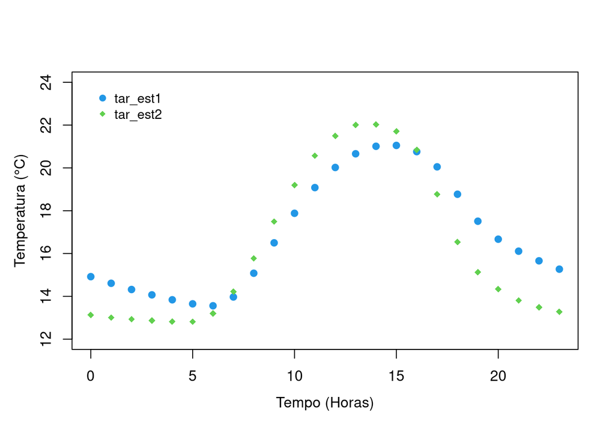

```r
tempo <- seq(from = 0, to = 23, by = 1)
plot(tempo, tar_est1, type = "p", pch = 19, col = 4, xlab = "", ylab = "", ylim = c(12,24))
points(tempo, tar_est2, col = 3, pch = 18)
mtext(side = 1, "Tempo (Horas)", line = 2.5, cex = 1)
mtext(side = 2, "Temperatura (°C)", line = 2.5, cex = 1)
legenda <- c("tar_est1","tar_est2")
legend(0, 24, legenda, col = c(4,3), pch = c(19,18), bty = "n", cex = 0.9, ncol = 1)
```

**a.** Determine a média diária da $T_{ar}$ das duas estações arrendondando para uma casa decimal. Salve a média de cada estação nas variáveis `tmed_est1` e `tmed_est2`.

```r
(tmed_est1 <- round(mean(tar_est1), 1))
```

```
#> [1] 16.9
```

```r
(tmed_est2 <- round(mean(tar_est2), 1))
```

```
#> [1] 16.3
```

**b**. Utilizando as variáveis do item anterior, verifique usando comparação lógica, em qual estação o ambiente é mais quente?

```r
print(c("A estação 2 é mais quente que a estação 1?", tmed_est1 < tmed_est2))
```

```
#> [1] "A estação 2 é mais quente que a estação 1?"
#> [2] "FALSE"
```

```r
print(c("A estação 1 é mais quente que a estação 2?", tmed_est1 > tmed_est2))
```

```
#> [1] "A estação 1 é mais quente que a estação 2?"
#> [2] "TRUE"
```

**c**. Obtenha a 3ª maior temperatura do dia em cada estação.

```r
# ordena o vetor tar_est1 em ordem crescente
order(tar_est1)
```

```
#>  [1]  7  6  5  8  4  3  2  1  9 24 23 22 10 21 20 11 19 12 13 18 14 17 15 16
```

```r
(T1_3rd <- tar_est1[17])
```

```
#> [1] 20.76
```

```r
#! tar_est1[order(tar_est1, decreasing = TRUE)][3]
#! rev(sort(tar_est1))[3]
order(tar_est2)
```

```
#>  [1]  6  5  4  3  2  1  7 24 23 22  8 21 20  9 19 10 18 11 12 17 13 16 14 15
```

```r
(T2_3rd <- tar_est2[16])
```

```
#> [1] 21.71
```

**d**. Calcule a amplitude térmica diária ($ATD = T_{max}-T_{min}$, onde $T_{max}$: temperatura máxima dária e $T_{min}$: temperatura mínima dária) das estações 1 e 2, arrendondando para uma casa decimal. Salve os resultados nas variaveis `atd_est1` e `atd_est2`.

```r
max1 <- which.max(tar_est1)
min1 <- which.min(tar_est1)
(atd_est1 <- round(tar_est1[max1] - tar_est1[min1], 1))
```

```
#> [1] 7.5
```

```r
max2 <- which.max(tar_est2)
min2 <- which.min(tar_est2)
(atd_est2 <- round(tar_est2[max2] - tar_est2[min2], 1))
```

```
#> [1] 9.2
```

```r
# em uma linha
#round(max(tar_est1) - min(tar_est1), 1))
```

> Falta de boas práticas: variáveis poderiam ter nomes com significado adequado.

**e**. Qual o horário de ocorrência das temperaturas máximas e mínimas em cada estação? Salve os resultados nas variáveis `hmax_est{i}` e `hmin_est{i}`, com $i = 1, 2$.

```r
(hmax_est1 <- max1) # errado
```

```
#> [1] 16
```

```r
 # tempo[which.max(tar_est1)] # correto
(hmin_est1 <- min1)
```

```
#> [1] 7
```

```r
(hmax_est2 <- max2)
```

```
#> [1] 15
```

```r
(hmin_est2 <- min2)
```

```
#> [1] 6
```

> Os horário corretos na est1 são 15 e 6. A variável que indica horário é a `hora` que vai de 0:23.

**f**. Quando `tar_est2` é maior que `tar_est1` qual a maior diferença absoluta de temperatura entre as duas estações?

```r
(h_dif <- which(tar_est2 > tar_est1))
```

```
#>  [1]  8  9 10 11 12 13 14 15 16 17
```

```r
(dif <- tar_est2 - tar_est1)
```

```
#>  [1] -1.79 -1.60 -1.39 -1.20 -1.02 -0.84 -0.36  0.25  0.69  0.99  1.32  1.49
#> [13]  1.47  1.35  1.02  0.66  0.08 -1.28 -2.23 -2.38 -2.33 -2.30 -2.17 -1.99
```

```r
(hora <- which.max(dif))
```

```
#> [1] 12
```

```r
(dif_max <- dif[hora])
```

```
#> [1] 1.49
```

**g**. Qual a hora correspondende a ocorrência daquela maior diferença absoluta de temperatura obtida no item anterior?

```r
(hora <- which.max(dif))
```

```
#> [1] 12
```

> Horário errado novamente.

**h**. O horário do pôr do sol pode ser estimado a partir da $T_{ar}$. Para o período após o horário de ocorrência da $T_{max}$ determina-se em qual hora ocorre a maior queda de $T_{ar}$ em relação a hora anterior. Estime o horário do pôr do sol para as duas estações (`hps_est{i}`).

```r
(dif_est1 <- diff(tar_est1[hmax_est1:23]))
```

```
#> [1] -0.29 -0.71 -1.28 -1.26 -0.84 -0.56 -0.45
```

```r
(h_dif_max <- which.max(abs(dif_est1)))
```

```
#> [1] 3
```

```r
# A hora da maior queda de temperatura registrada pela estação 1 ocorre 3 horas
# após o registro da temperatura máxima

# Horário do pôr do Sol para a estação 1
(hps_est1 <- hmax_est1 + h_dif_max)
```

```
#> [1] 19
```

```r
(dif_est2 <- diff(tar_est2[hmax_est2:23]))
```

```
#> [1] -0.32 -0.87 -2.07 -2.23 -1.41 -0.79 -0.53 -0.32
```

```r
(h_dif_max2 <- which.max(abs(dif_est2)))
```

```
#> [1] 4
```

```r
# A hora da maior queda de temperatura registrada pela estação 2 ocorre 4 horas
# após o registro da temperatura máxima

# Horário do pôr do Sol para a estação 2
(hps_est2 <- hmax_est2 + h_dif_max)
```

```
#> [1] 18
```

> Horário errado novamente. tempo[hps_est1] é o correto.

**i**. Em quais horas as temperaturas das duas estações estão mais próximas uma da outra, ou seja com menos de 0,5°C de diferença ?

```r
(dif_est <- abs(tar_est1 - tar_est2))
```

```
#>  [1] 1.79 1.60 1.39 1.20 1.02 0.84 0.36 0.25 0.69 0.99 1.32 1.49 1.47 1.35 1.02
#> [16] 0.66 0.08 1.28 2.23 2.38 2.33 2.30 2.17 1.99
```

```r
(menor_dif <- which(dif_est < 0.5))
```

```
#> [1]  7  8 17
```

> Horários errados. tempo[menor_dif] é o correto.

**j**. Calcule a temperatura média diária usando os seguintes métodos para estação 2.

$T_{med_{1}} = (T_{max} + T_{min})/2$, salvando em uma variável `tar_met1`.

```r
# método 1:

Tmax2 <- tar_est2[which.max(tar_est2)]
Tmin2 <- tar_est2[which.min(tar_est2)]

(tar_met1 <- (Tmax2 + Tmin2)/2)
```

```
#> [1] 17.42
```

$T_{med_{2}} = (T_{max} + T_{min} + T_{9} + 2T_{21})/5$, salvando em uma variável `tar_met2`.

```r
# método 2:

(tar_met2 <- (Tmax2 + Tmin2 + tar_est2[9] + 2* tar_est2[21])/5)  # errado
```

```
#> [1] 15.858
```

```r
(tar_met2_cor <- (Tmax2 + Tmin2 + tar_est2[tempo == 9] + 2* tar_est2[tempo == 21])/5) # correto
```

```
#> [1] 15.99
```

$T_{med_{3}} = (T_{7} + T_{14} + 2T_{21})/4$, salvando em uma variável `tar_met3`.

```r
# método 3:

(tar_met3 <- (tar_est2[7] + tar_est2[14] + 2*tar_est2[21])/4) # errado
```

```
#> [1] 15.9725
```

```r
(tar_met3_cor <- (tar_est2[tempo == 7] + tar_est2[tempo == 14] + 2*tar_est2[tempo == 21])/4) # correto
```

```
#> [1] 15.9675
```

Compare este resultados com aqueles obtidos no item **a**. Qual é melhor?

> Você deveria mostrar isso com seu código. Como você chegou a essa conclusão? que cálculo mental não expresso aqui que você fez para afirmar isso?

> O método 2 é o mais próximo à média das 24 h. Corrija seus cálculos e verifique.

```r
dif_abs_mets_est2 <- c(
  m1 = tar_met1 - tmed_est2,
  m2 = tar_met2_cor - tmed_est2,
  m3 = tar_met3_cor - tmed_est2
)
dif_abs_mets_est2
```

[output not shown]

```r
dif_abs_mets_est2[which.min(abs(dif_abs_mets_est2))]
```

```
#>    m2
#> -0.31
```

```
JDT> [1] 0.5
```